# Etude sur la flotte de TunisAir

The Mean_Squares

15/10/2018

# Plan de travail: (CRISP)

## I - Compréhension métier

### 1) Problématique

### 2) Démarche à suivre

## II - Compréhension des données

### 1) Collecte des données

### 2) Exploration des données

## III - Préparation des données

## I - Compréhension métier

### 1) Problématique

- Est-ce que la flotte actuelle de Tunisair répond aux exigences internationales ?
- Peut-on affirmer que les modèles disponibles dans la compagnie tunisienne joignent les normes standards favorisant la concurrence sur l’échelle régionale et/ou internationale ?
- Comment peut-on catégoriser une telle panoplie de modèles d’avions ?
- Quel est le profil typique des avions dans le monde ?

### 2) Démarche à suivre

- Dans ce projet, nous allons répondre à la problématique moyennant la méthode CRISP et suivant cette stratégie:  
  Nous allons étudier la flotte de Tunisair selon deux principaux critères:
1. Les caractéristiques de la flotte de Tunsair et ceux des compagnies aériennes dans le monde.
2. Les équipements des avions de la flotte de Tunisair et des compagnies aériennes dans le monde.

## II - Compréhension des données

### 1) Collecte des données

- Voir le rapport *Data_Collection.html*

### 2) Exploration des données

Nous disposons de deux datasets collectés précédemment:  
- *Fleet.csv*  
- *Fleet_Equipments.csv*

Commençons par *Fleet.csv* !

- Importation du dataset:

```r
fleet<- read.csv(file = "Fleet.csv", header = T ,sep=",",dec = ".")
fleet$X<- NULL
```

```r
str(fleet)
```

```
## 'data.frame':    110 obs. of  7 variables:
##  $ Airline    : Factor w/ 110 levels "Aegean Airlines",..: 1 3 4 5 6 7 8 9 11 12 ...
##  $ Short_Haul : int  47 40 46 38 1 5 23 115 97 275 ...
##  $ Long_Haul  : int  0 14 10 0 0 0 8 15 69 100 ...
##  $ Average_Age: num  11.6 13.5 15.2 4.7 11.4 6.2 10.1 10.5 16.3 7.7 ...
##  $ Total      : int  47 54 56 38 1 5 31 130 166 375 ...
##  $ IATA       : Factor w/ 107 levels "3O","4U","9W",..: 4 12 10 45 31 1 56 6 7 24 ...
##  $ dest       : int  222 154 234 130 10 44 118 798 705 1260 ...
```

```r
sum(is.na(fleet))
```

```
## [1] 0
```

- Ce dataset ne comporte aucune valeur manquante.
- Vue génerale du dataset:

```r
summary(fleet)
```

```
##                   Airline      Short_Haul       Long_Haul
##  Aegean Airlines      :  1   Min.   :  0.00   Min.   :  0.00
##  Aer Lingus           :  1   1st Qu.: 26.25   1st Qu.:  0.00
##  Aerolineas Argentinas:  1   Median : 44.00   Median :  8.00
##  Air Algerie          :  1   Mean   : 82.46   Mean   : 29.87
##  Air Arabia           :  1   3rd Qu.: 81.75   3rd Qu.: 26.75
##  Air Arabia Egypt     :  1   Max.   :733.00   Max.   :253.00
##  (Other)              :104
##   Average_Age        Total             IATA          dest
##  Min.   : 3.80   Min.   :  1.00   I9     :  2   Min.   :   1.0
##  1st Qu.: 7.80   1st Qu.: 34.75   LH     :  2   1st Qu.: 120.5
##  Median :10.10   Median : 63.00   SQ     :  2   Median : 212.5
##  Mean   :10.92   Mean   :112.34   3O     :  1   Mean   : 352.8
##  3rd Qu.:13.45   3rd Qu.:123.75   4U     :  1   3rd Qu.: 368.8
##  Max.   :23.90   Max.   :928.00   9W     :  1   Max.   :2484.0
##                                   (Other):101
```

Passons à *Fleet_Equipments.csv* !

- Importation du dataset:

```r
fleetEq<- read.csv(file = "Fleet_Equipments.csv", header = T ,sep=",",dec = ".")
fleetEq$X<- NULL
```

```r
str(fleetEq)
```

```
## 'data.frame':    1379 obs. of  19 variables:
##  $ Airline                     : Factor w/ 152 levels "Aegean Airlines",..: 1 1 1 1 1 2 2 2 2 2 ...
##  $ Aircraft                    : Factor w/ 429 levels "Aerospatiale ATR-42",..: 11 27 133 364 52 27 52 77 78 88 ...
##  $ Seat.Pitch..Economy.        : num  30 30 30 30 30 31.5 31.5 31.5 31.5 31.5 ...
##  $ Seat.Width..Economy.        : num  18 18 17 17 18 17 17 17 17 17 ...
##  $ Seat.Pitch..Premium.Economy.: num  0 0 0 0 0 0 0 0 0 0 ...
##  $ Seat.Width..Premium.Economy.: num  0 0 0 0 0 0 0 0 0 0 ...
##  $ Seat.Pitch..First.Business. : num  33 33 0 0 33 0 0 58 58 58 ...
##  $ Seat.Width..First.Business. : num  18 18 0 0 18 0 0 21 21 21 ...
##  $ Seat.Pitch..VIP.            : num  0 0 0 0 0 0 0 0 0 0 ...
##  $ Seat.Width..VIP.            : num  0 0 0 0 0 0 0 0 0 0 ...
##  $ Wifi                        : int  0 0 0 0 0 0 0 1 1 1 ...
##  $ Video                       : int  0 1 0 0 1 0 0 1 1 1 ...
##  $ Power                       : int  0 0 0 0 0 0 0 1 1 1 ...
##  $ Sleeper                     : int  0 0 0 0 0 0 0 0 0 0 ...
##  $ Video.Type                  : Factor w/ 7 levels "None","On-Demand TV",..: 1 3 1 1 3 1 1 2 2 2 ...
##  $ Laptop.Power                : Factor w/ 3 levels "All Seats","None",..: 2 2 2 2 2 2 2 1 1 1 ...
##  $ Power.Type                  : Factor w/ 3 levels "AC Power","DC Power",..: 3 3 3 3 3 3 3 1 1 1 ...
##  $ Seat.Type                   : Factor w/ 4 levels "Angle Lie Flat",..: 4 4 4 4 4 4 4 4 4 4 ...
##  $ Haul                        : Factor w/ 2 levels "Long","Short": 2 2 2 2 1 2 2 1 1 1 ...
```

```r
sum(is.na(fleetEq))
```

```
## [1] 0
```

- Ce dataset ne comporte aucune valeur manquante.
- Vue génerale du dataset:

```r
summary(fleetEq)
```

```
##               Airline                      Aircraft
##  United           :  83   Airbus A320 (320)    :  59
##  Delta            :  64   Boeing 737-800 (738) :  45
##  American Airlines:  62   Airbus A319 (319)    :  44
##  China Southern   :  33   Airbus A321 (321)    :  37
##  Air France       :  31   Airbus A330-200 (332):  33
##  Air Canada       :  30   Airbus A330-300 (333):  33
##  (Other)          :1076   (Other)              :1128
##  Seat.Pitch..Economy. Seat.Width..Economy. Seat.Pitch..Premium.Economy.
##  Min.   : 0.00        Min.   : 0.00        Min.   : 0.000
##  1st Qu.:31.00        1st Qu.:17.00        1st Qu.: 0.000
##  Median :31.50        Median :17.50        Median : 0.000
##  Mean   :31.66        Mean   :17.43        Mean   : 4.615
##  3rd Qu.:32.50        3rd Qu.:18.00        3rd Qu.: 0.000
##  Max.   :60.00        Max.   :20.20        Max.   :47.000
##
##  Seat.Width..Premium.Economy. Seat.Pitch..First.Business.
##  Min.   : 0.000               Min.   :  0.0
##  1st Qu.: 0.000               1st Qu.:  0.0
##  Median : 0.000               Median : 38.0
##  Mean   : 2.281               Mean   : 37.4
##  3rd Qu.: 0.000               3rd Qu.: 60.0
##  Max.   :21.000               Max.   :103.0
##
##  Seat.Width..First.Business. Seat.Pitch..VIP. Seat.Width..VIP.
##  Min.   : 0.00               Min.   : 0.000   Min.   : 0.000
##  1st Qu.: 0.00               1st Qu.: 0.000   1st Qu.: 0.000
##  Median :20.00               Median : 0.000   Median : 0.000
##  Mean   :14.97               Mean   : 7.092   Mean   : 2.266
##  3rd Qu.:21.00               3rd Qu.: 0.000   3rd Qu.: 0.000
##  Max.   :42.00               Max.   :90.000   Max.   :36.000
##
##       Wifi            Video            Power           Sleeper
##  Min.   :0.0000   Min.   :0.0000   Min.   :0.0000   Min.   :0.000000
##  1st Qu.:0.0000   1st Qu.:0.0000   1st Qu.:0.0000   1st Qu.:0.000000
##  Median :0.0000   Median :1.0000   Median :0.0000   Median :0.000000
##  Mean   :0.3002   Mean   :0.6592   Mean   :0.3249   Mean   :0.006527
##  3rd Qu.:1.0000   3rd Qu.:1.0000   3rd Qu.:1.0000   3rd Qu.:0.000000
##  Max.   :1.0000   Max.   :1.0000   Max.   :1.0000   Max.   :1.000000
##
##            Video.Type      Laptop.Power    Power.Type
##  None           :470   All Seats :370   AC Power:446
##  On-Demand TV   :548   None      :941   DC Power:  2
##  Overhead TV    :211   Some Seats: 68   None    :931
##  Portable Device: 40
##  Satellite TV   : 14
##  Seatback TV    : 90
##  Yes            :  6
##           Seat.Type       Haul
##  Angle Lie Flat:   2   Long :595
##  Flat Bed      :   2   Short:784
##  Recliner      :   5
##  Standard      :1370
##
##
##
```

## III - Préparation des données

Les données sont déjà prêts, cette étape a été accomplie dans le rapport *Data_Collection.html*

## IV - Modélisation

- Statistique descriptive du dataset *fleet*: Nous allons comparer Tunisair aux compagnies aériennes sur le plan international à travers plusieurs facteurs:
1. Moyenne d’âge :

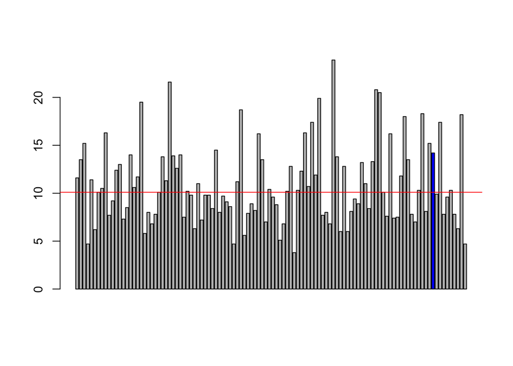

```r
barplot(fleet$Average_Age,col=ifelse(fleet$Airline == "Tunisair","blue","gray"))
abline(h = median(fleet$Average_Age),col = "red")
```

2. Nombre d’avions:

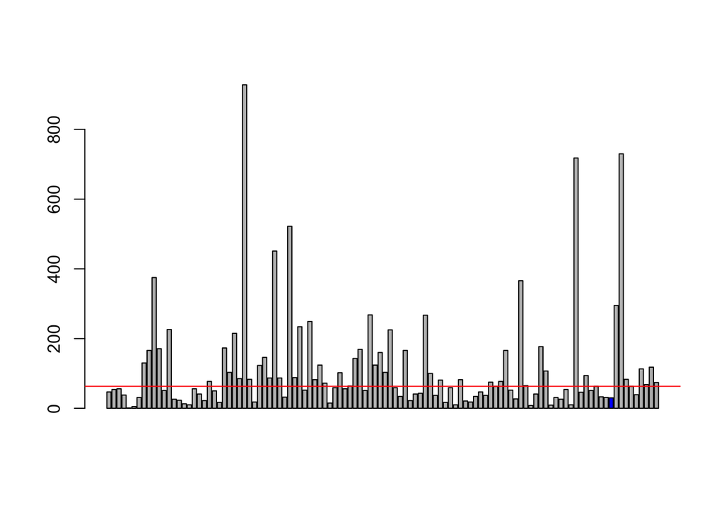

```r
barplot(fleet$Total,col=ifelse(fleet$Airline == "Tunisair","blue","gray"))
abline(h = median(fleet$Total),col = "red")
```

- Segmentation des flottes aériennes présents dans le dataset *fleet*:

On determine le nombre de clusters adéquoit avec la méthode *Somme des carrés pondérés*:

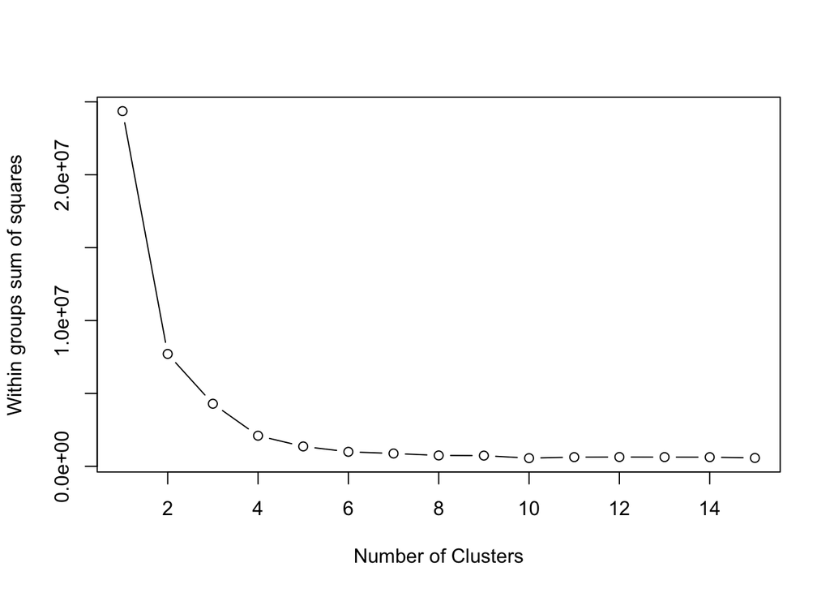

```r
fleet2<-fleet
fleet2$Short_Haul = NULL
fleet2$Long_Haul = NULL
fleet2$IATA = NULL
wss <- (nrow(fleet2[,-c(1,6)])-1)*sum(apply(fleet2[,-c(1,6)],2,var))
for (i in 2:15) wss[i] <- sum(kmeans(fleet2[,-c(1,6)],
                                    centers=i)$withinss)
plot(1:15, wss, type="b", xlab="Number of Clusters",
    ylab="Within groups sum of squares")
```

On choisit 4 comme nombre de clusters:

```r
set.seed(4455)
fleet2$cluster = kmeans(fleet2[,-c(1,6)],4)$cluster
```

On determine le cluster qui contient tunisair et les compagnies similaires de point de vue taille des flottes,moyennes d’ages et nombre des vols programmés

```r
fleet2[which(fleet2$Airline=="Tunisair"),-1]
```

```
##     Average_Age Total dest cluster
## 101        14.2    30  151       1
```

```r
tunisair_cluster = fleet2[which(fleet2$cluster == 1),]
tunisair_cluster$cluster = NULL
cor(tunisair_cluster[,-c(1,6)])
```

```
##             Average_Age      Total      dest
## Average_Age   1.0000000 -0.1099151 0.2270564
## Total        -0.1099151  1.0000000 0.5706229
## dest          0.2270564  0.5706229 1.0000000
```

```r
tunisair_cluster$Average_Age = NULL
tunisair_cluster$Airline = NULL
tunisair_cluster$dest = as.integer(tunisair_cluster$dest)
write.csv(tunisair_cluster,"tunisaircluster.csv")
```

On effectue une régression linaire simple afin de prédire le nombre de vols supposés assurés par Tunisair

```python
import numpy as np
import matplotlib.pyplot as plt
import pandas as pd
# Importer le dataset
dataset = pd.read_csv("tunisaircluster.csv")
X = dataset.iloc[:, 1].values
y = dataset.iloc[:, -1].values
# Diviser le dataset entre le Training set et le Test set
from sklearn.cross_validation import train_test_split
X_train, X_test, y_train, y_test = train_test_split(X, y, test_size = 0.2, random_state = 0)
# Construction du modèle
from sklearn.linear_model import LinearRegression
regressor = LinearRegression()
regressor.fit(X_train.reshape(-1,1), y_train)
# Faire de nouvelles prédictions
y_pred = regressor.predict(30)
print(y_pred)
```

```
## [116.97177978]
```

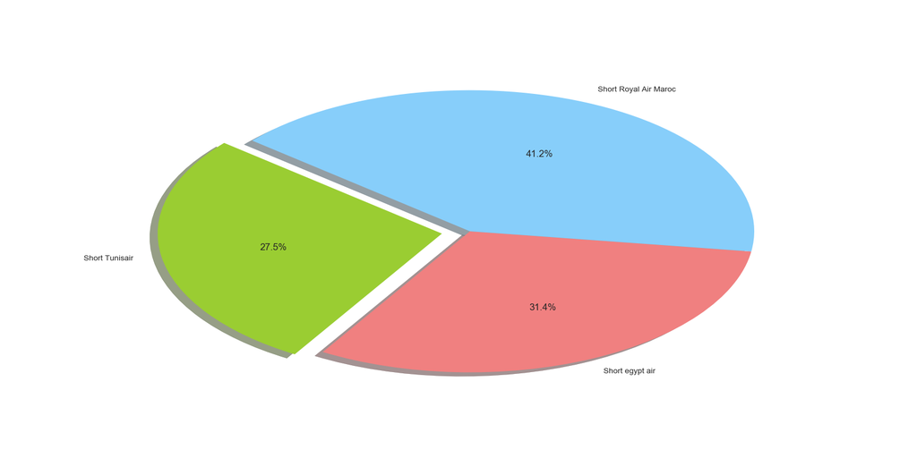

```python
import numpy as np
import matplotlib.pyplot as plt
import pandas as pd
import seaborn as sns; sns.set()
#import plotly
dataset= pd.read_csv("final_dataset.csv",delimiter=",")
dataset.columns
dataset.describe()
tunisia=dataset.loc[dataset['Airline']=='Tunisair']
egypt=dataset.loc[dataset['Airline']=='EgyptAir']
maroc=dataset.loc[dataset['Airline']=='Royal Air Maroc']
african=pd.DataFrame()
african=tunisia
african=african.append(egypt)
african=african.append(maroc)
colors = ['yellowgreen', 'lightcoral', 'lightskyblue']
explode = (0.1, 0, 0)  # explode 1st slice
fig = plt.figure(figsize=(16,8))
ss=[tunisia['Short_Haul'].values,egypt['Short_Haul'].values,maroc['Short_Haul'].values]
Label= "Short Tunisair","Short egypt air","Short Royal Air Maroc"
ss
colors = ['yellowgreen', 'lightcoral', 'lightskyblue']
explode = (0.1, 0, 0)  # explode 1st slice
# we can see that Royal Air maroc have the better number of fleet comparing to tunnisia and africa
# comaparaison between maroc tunisia and south africa
# Plot
plt.pie(ss, explode=explode, labels=Label, colors=colors,
       autopct='%1.1f%%', shadow=True, startangle=140)
fig.savefig("pyplot.png")
plt.close(fig)
```

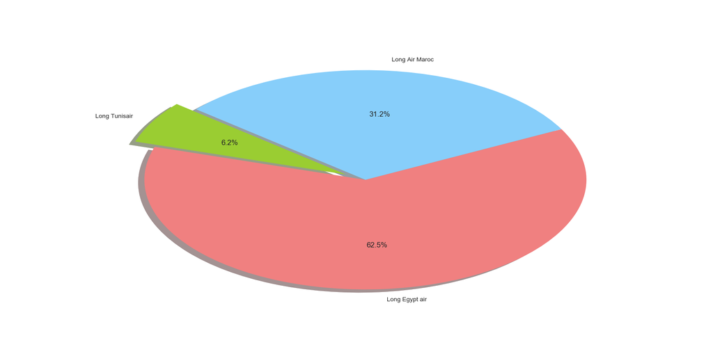

```python
import numpy as np
import matplotlib.pyplot as plt
import pandas as pd
import seaborn as sns; sns.set()
#import plotly
colors = ['yellowgreen', 'lightcoral', 'lightskyblue']
fig = plt.figure(figsize=(16,8))
dataset= pd.read_csv("final_dataset.csv",delimiter=",")
explode = (0.1, 0, 0)  # explode 1st slice
tunisia=dataset.loc[dataset['Airline']=='Tunisair']
egypt=dataset.loc[dataset['Airline']=='EgyptAir']
maroc=dataset.loc[dataset['Airline']=='Royal Air Maroc']
sss=[tunisia['Long_Haul'].values,egypt['Long_Haul'].values,maroc['Long_Haul'].values]
Label1= "Long Tunisair","Long Egypt air","Long Air Maroc"
plt.pie(sss, explode=explode, labels=Label1, colors=colors,
       autopct='%1.1f%%', shadow=True, startangle=140)
fig.savefig("pyplot1.png")
```

On constate que Tunisair a pourcentrage très mediocre par rapport à Long egypt air et Long Air Maroc et donc on peut conclure que Tunisair ne peut pas concurrencer les autres flottes dans les vols long courriers.

- Segmentation des flottes aériennes présents dans le dataset *fleetEquipements*:
- Ajout d’une nouvelle colonne (Origine) pour vérifier si la flotte de Tunisair est incluse dans le Cluster majoritaire des flottes étrangeres ou pas.

```r
fleetEq$origine <- ifelse(fleetEq$Airline =="Tunis Air","Tunisair", "Etrangere")
```

- CAH CLUSTING

```r
quantiData111<-fleetEq[3:14]
distData111<-dist(quantiData111)
Data111_HH<-hclust(distData111, method="average")
```

- Dendrogramme

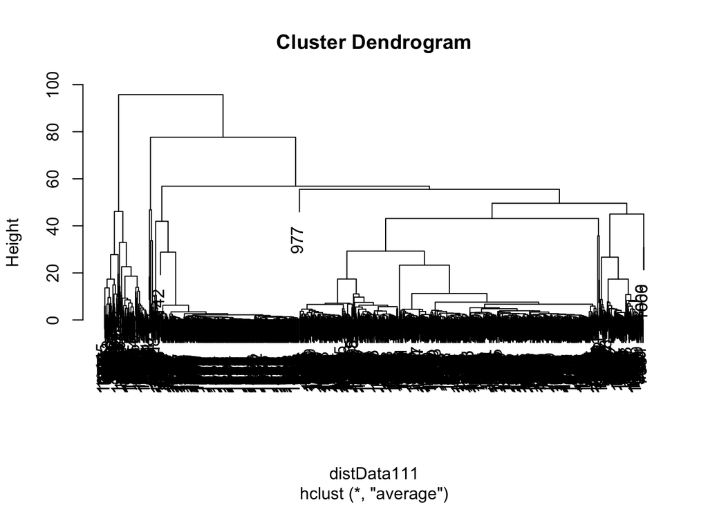

```r
plot(Data111_HH)
```

- On voit clairement qu’il y’a 3 Clusters principaux

```r
Data111_CH<-cutree(Data111_HH , 3 )
```

- Vérifions si la Flotte de Tunisair fait partie du Cluster le plus imposant (incluant la majorité des Flottes )

```r
table(fleetEq$origine, Data111_CH  )
```

```
##            Data111_CH
##                1    2    3
##   Etrangere 1246  114   14
##   Tunisair     5    0    0
```

```r
fleetEq$cluster = Data111_CH
```

```r
table(fleetEq$Haul,fleetEq$cluster)
```

```
##
##           1   2   3
##   Long  467 114  14
##   Short 784   0   0
```

- Les modèles d’avions des Cluster 2 et 3 sont tous de long courrier

```r
nrow(fleetEq[which(fleetEq$`Seat.Pitch..VIP.` == 0 & fleetEq$cluster != 1),])
```

```
## [1] 0
```

```r
nrow(fleetEq[which(fleetEq$`Seat.Pitch..VIP.` == 0 & fleetEq$cluster == 1),])
```

```
## [1] 1251
```

- Les Modeles d’Avions du Cluster 1 be dispose d’aucune classe VIP (c’est donc le cas pour les avions de Tunisair), tandis que ceux des Cluster 2 et 3 disposent tous de classe VIP

-Qu’en est t’il des spécifications des Cluster 2 et 3

-On a Comparé la disposition de Class Business (Par rapport au Seat Pitch First Business)

```r
nrow(fleetEq[which(fleetEq$`Seat.Pitch..First.Business.` == 0 & fleetEq$cluster == 2),])
```

```
## [1] 0
```

```r
nrow(fleetEq[which(fleetEq$`Seat.Pitch..First.Business.` == 0 & fleetEq$cluster == 3),])
```

```
## [1] 14
```

```r
nrow(fleetEq[which(fleetEq$`Seat.Pitch..First.Business.` == 0 & fleetEq$Airline == "Tunisair"),])
```

```
## [1] 0
```

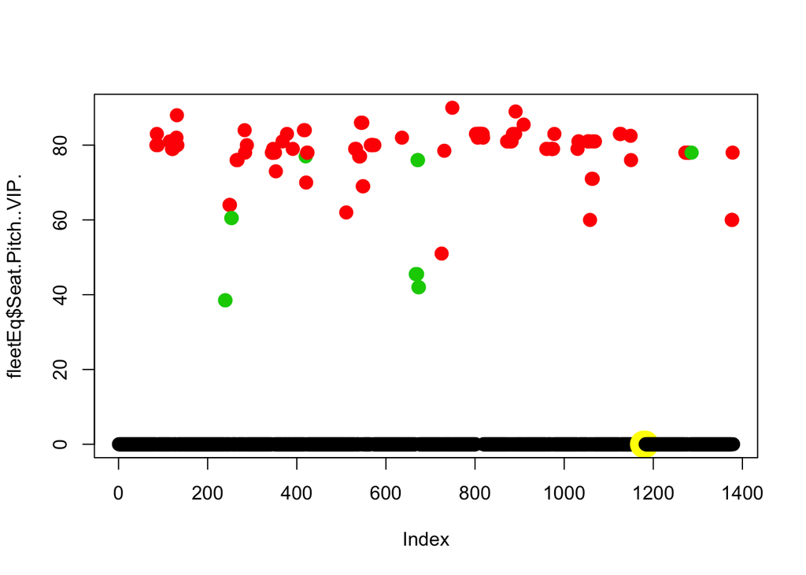

```r
plot ( fleetEq$`Seat.Pitch..VIP.` , col=ifelse(fleetEq$Airline == "Tunis Air","yellow",Data111_CH) , pch=19 , cex=ifelse(fleetEq$Airline == "Tunis Air",3,1.5))
```

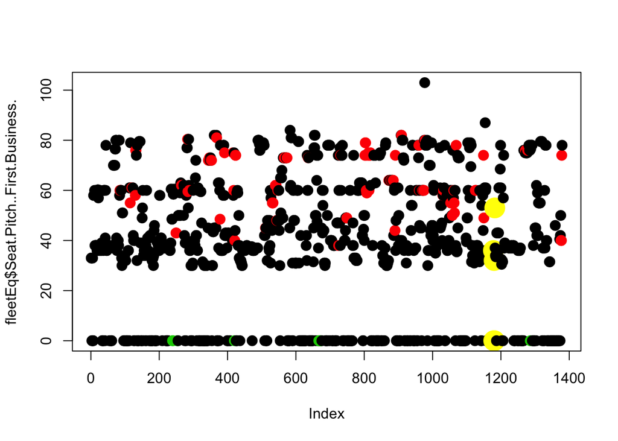

```r
plot ( fleetEq$`Seat.Pitch..First.Business.` , col=ifelse(fleetEq$Airline == "Tunis Air","yellow",Data111_CH) , pch=19 , cex=ifelse(fleetEq$Airline == "Tunis Air",3,1.5))
```

- On peut Clairement Affirmer que la Classe First Business a répartit les 2 Clusters 2 et 3 qui se joignent dans la disponibilité de Classe VIP par rapoort au Cluster 1, mais il n’entre pas dans les facteurs Globaux qui caractérisent Chaque Cluster étant donné qu’une Bonne majorité du Cluster 1 ont la Classe Business.
- Ce qui nous amene a conclure que le Facteur Majeur qui a répartit les Clusters est “Luxe et Confort”,Le Cluster 2: “Luxieux” avec 114 modeles, Cluster 3: “Moyennement Luxieux” avec 14 modeles, Cluster 1: “Pas assez Luxieux” avec 1246 modeles, et Tunisair fait Partie du Cluster le moins Luxieux.

## V - Interprétation

Tunisair est caractérisée par une panoplie d’avions comme suit:

- Moyenne d’age de la flotte élevée.
- Nombre de vols plus important que la normale (Surexploitation de la flotte).
- Nombre d’avions en dessous de la norme.
- La flotte ne contient pas d’avions luxieux.

# Conclusion

Pour remédier aux problèmes cités ci-dessus, il est imperatif que Tunisair renforce sa flotte aérienne afin de baisser la charge imposée sur la flotte actuelle, notemment des avions capables d’executer des longs courrier afin de pouvoir faire face à la concurrence.

Dans cette optique, Tunisair à déjà commandé 5 avions long courrier de type A320-NEO.